# Exercise 2 : Vector data, Administrative boudaries and Open Street Maps

2024-03-05

### Key packages

- Geo-computations : sf, terra, raster
- Plotting : ggplot2, ggrepel, gridExtra, ggspatial, grid
- Geocoding : tidygeocoder
- R Project management: here
- Generic data wrangling : dplyr, tidyr
- Map of the world : rnaturalearth and rnaturalearth
- Country and admin names : countrycode
- Open street maps : osrm

One of the most common tasks in applied economics is to analyze phenomena across or within administrative unit borders. Frequently this is the level at which survey data are geo-located, not always though sometimes you can be lucky enough that you have the geo-location of each household in the sample but it is quite rare.

Being geo-located just means that in the survey data that you are using you have the name or the code of the municipality where the surveyed individuals or household are located. To actually bring the data into a spatial framing you need to merge your survey data with a shapefile of the administrative boundaries of the country you are working with.

To download administrative boundaries for all countries in the world this website is very useful and free: https://gadm.org/download_country.html Here you can choose the country and the administrative level you are interested in.

Usually admin0 or admin1 is the biggest unit so the country it self, while admin2 is region or provinces and admin3 is the municipality or the county (similar to NUTS1, NUTS2 and NUTS3 if you are familiar with EU data). Administrative boundaries can be defined differently country by country and can change through time.

Now we will download from GADM boundaries at the smallest available level for Germany and look at them using the sf package.

Remember that we are opening only the file that ends with .shp but for it to work we should have ion the same folder and having the same name also other three files ending respectively with .prj , .dbf , .cpg , .shx

Starting with admin 0 that is the all country

```r
deu_0 <- st_read(here("data","raw", "gadm41_DEU_shp", "gadm41_DEU_0.shp"))
```

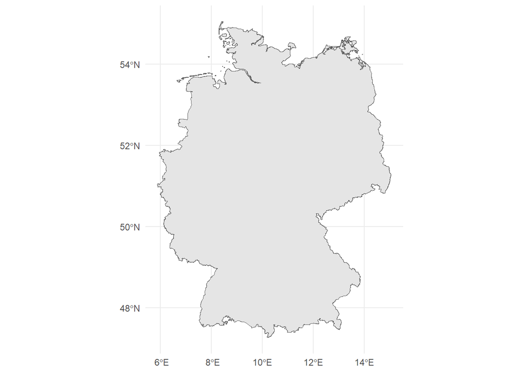

```r
admin_0 <- ggplot()+
  geom_sf(data = deu_0)+
  theme_minimal()
print(admin_0)
```

Then Admin 1 that for Germany is states

```r
deu_1 <- st_read(here("data","raw", "gadm41_DEU_shp", "gadm41_DEU_1.shp"))
```

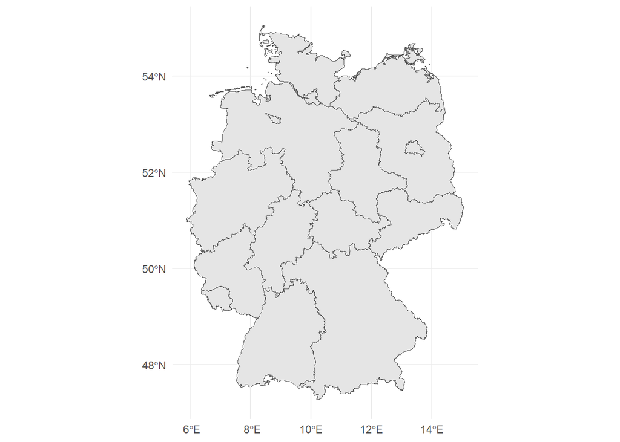

```r
admin_1 <- ggplot()+
  geom_sf(data = deu_1)+
  theme_minimal()
print(admin_1)
```

Then Admin 2 that is regions

```r
deu_2 <- st_read(here("data","raw", "gadm41_DEU_shp", "gadm41_DEU_2.shp"))
```

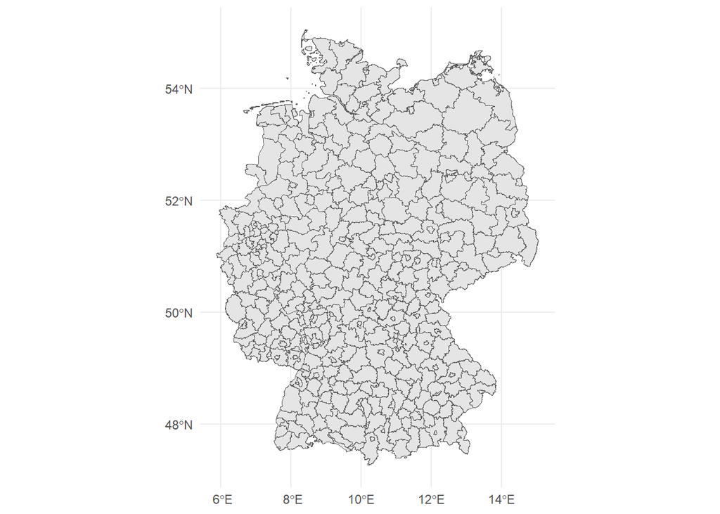

```r
admin_2 <- ggplot()+
  geom_sf(data = deu_2)+
  theme_minimal()
print(admin_2)
```

Then Admin 3 that is provinces

```r
deu_3 <- st_read(here("data","raw", "gadm41_DEU_shp", "gadm41_DEU_3.shp"))
```

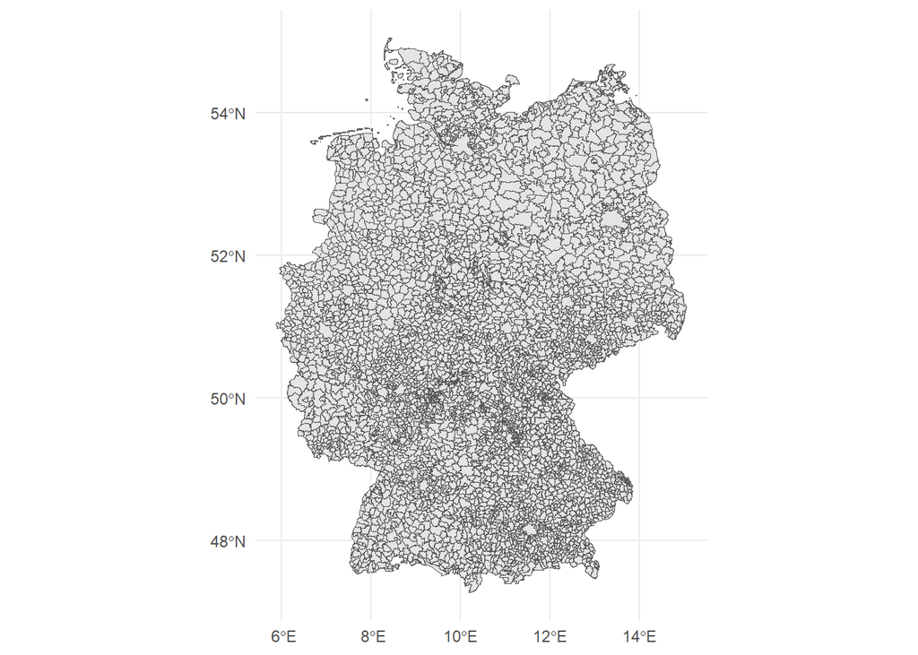

```r
admin_3 <- ggplot()+
  geom_sf(data = deu_3)+
  theme_minimal()
print(admin_3)
```

And finally Admin4 that is municipalities

```r
deu_4 <- st_read(here("data","raw", "gadm41_DEU_shp", "gadm41_DEU_4.shp"))
```

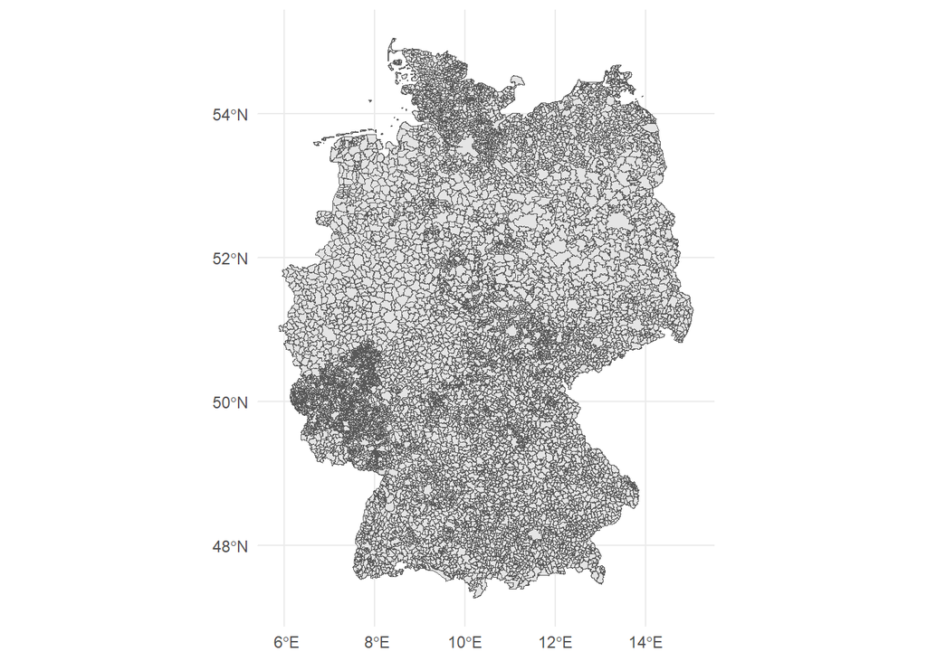

```r
admin_4 <- ggplot()+
  geom_sf(data = deu_4)+
  theme_minimal()
print(admin_4)
```

### Cropping and selecting areas of interest

Many times we are interested in a particular area of a country or a region and we can restrict the data to a smaller area of interest employing different strategies.

Now let´s say we want to have data only on Saxony or Dresden.

We can look at the names in the dataset for Admin 1 or Amdin 2 and filter like for normal a data.frame

```r
names(deu_1)
```

```
##  [1] "GID_1"     "GID_0"     "COUNTRY"   "NAME_1"    "VARNAME_1" "NL_NAME_1"
##  [7] "TYPE_1"    "ENGTYPE_1" "CC_1"      "HASC_1"    "ISO_1"     "geometry"
```

```r
table(deu_1$NAME_1)
```

```
##
##      Baden-Württemberg                 Bayern                 Berlin
##                      1                      1                      1
##            Brandenburg                 Bremen                Hamburg
##                      1                      1                      1
##                 Hessen Mecklenburg-Vorpommern          Niedersachsen
##                      1                      1                      1
##    Nordrhein-Westfalen        Rheinland-Pfalz               Saarland
##                      1                      1                      1
##                Sachsen         Sachsen-Anhalt     Schleswig-Holstein
##                      1                      1                      1
##              Thüringen
##                      1
```

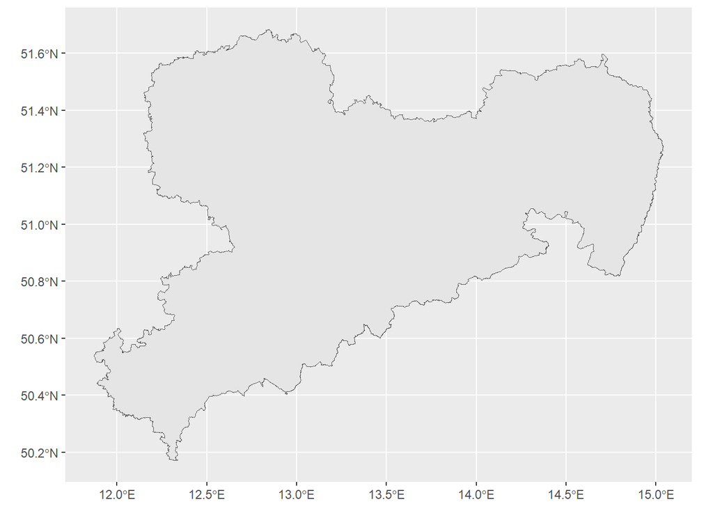

```r
saxony  <- deu_1|>
  filter(NAME_1 == "Sachsen")

saxon_plot <- ggplot()+
  geom_sf(data = saxony)

print(saxon_plot)
```

```r
names(deu_4)
```

```
##  [1] "GID_4"     "GID_0"     "COUNTRY"   "GID_1"     "NAME_1"    "GID_2"
##  [7] "NAME_2"    "GID_3"     "NAME_3"    "NAME_4"    "VARNAME_4" "TYPE_4"
## [13] "ENGTYPE_4" "CC_4"      "geometry"
```

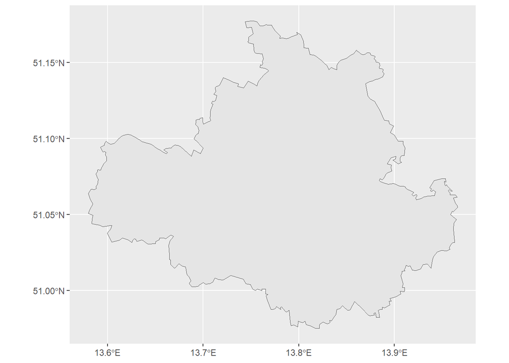

```r
dresden <- deu_4 |>
  filter(NAME_4 == "Dresden")

dresden_plot <- ggplot()+
  geom_sf(data = dresden)

print(dresden_plot)
```

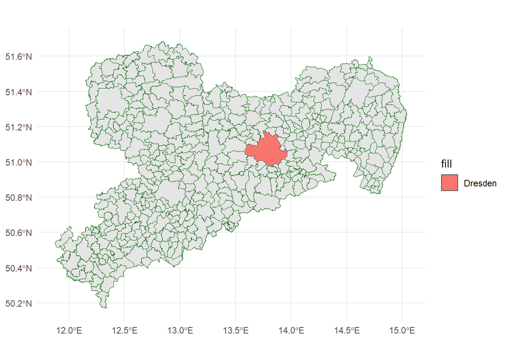

```r
### We can also combine different levels of admin, just keep in mind that the more granular you go the more names will be there but the geometry will always be at the level at which you downloaded it, so we can get a more detailed picture of Saxony using the admin 4 level data and then add a layer with only dresden in a different color for eg.


detailed_saxon <- deu_4 |>
  filter(NAME_1 == "Sachsen")

detailed_saxon_plot <- ggplot() +
  geom_sf(data = detailed_saxon, colour= "darkgreen")+
  geom_sf(data = dresden,
          aes(fill = "Dresden")) +
  theme_minimal()

print(detailed_saxon_plot)
```

Let´s say we want to have data only on Dresden area covered by trams :

We can take our tramline data and use their extent to crop our admin 4 data on Dresden area.

To do it we use the function crop(data_to_be_cropped, desired_extent) from the terra package

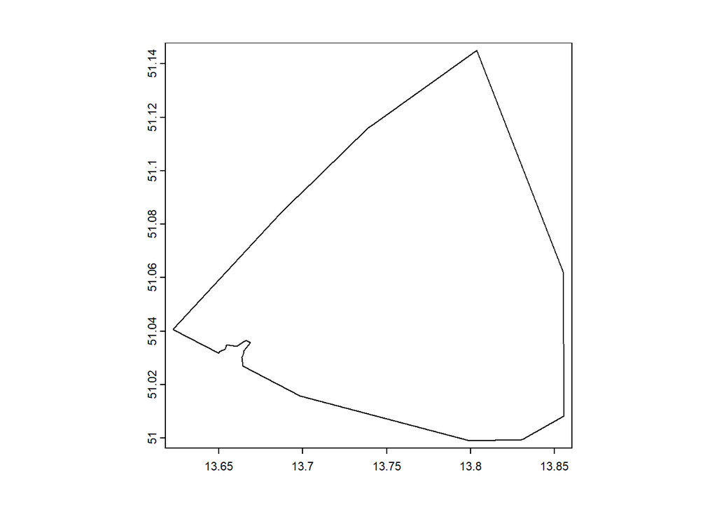

```r
tram_lines <- read.csv(here("data", "raw", "tram_lines.csv"),sep=';')

tram_sf <- st_as_sf(tram_lines, wkt = "geom")

# convert to spatvectors

tram_terra <- vect(tram_sf)
dresden_terra <-vect(dresden)

area_tram <- crop(dresden_terra, tram_terra)


terra::plot(area_tram)
```

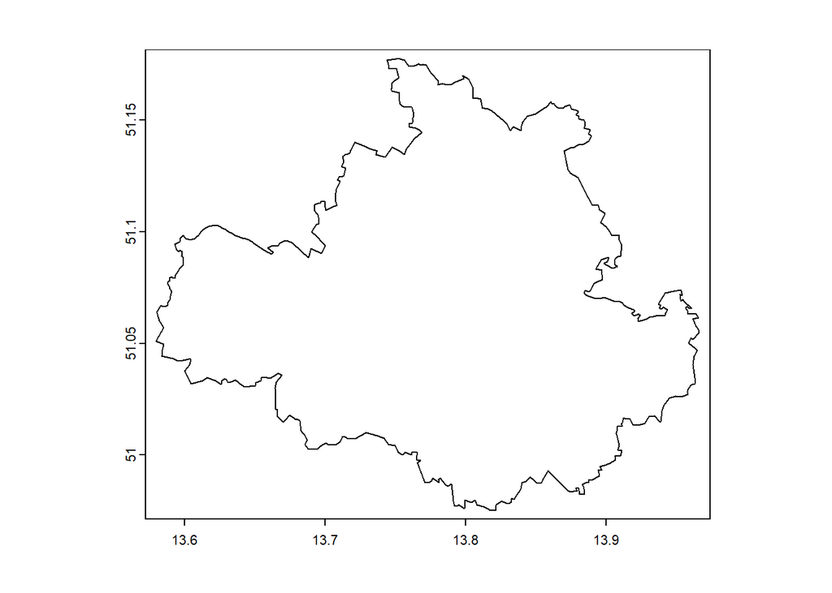

```r
terra::plot(dresden_terra)
```

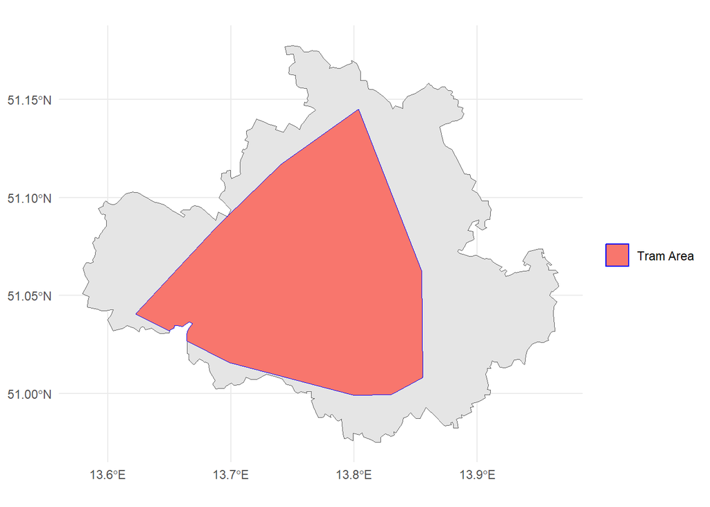

```r
### One drawback of terra is that spat objects are not coercible by the fortify function that runs in ggplot so we convert back to sf before plotting the two together

area_tram_sf <- st_as_sf(area_tram)


tram_area_plot <- ggplot() +
  geom_sf(data = dresden) +
  geom_sf(data = area_tram_sf, aes(fill = "Tram Area"), colour = "blue") +
  labs(fill = "") +
  theme_minimal()

print(tram_area_plot)
```

We can also add the markets on the map:

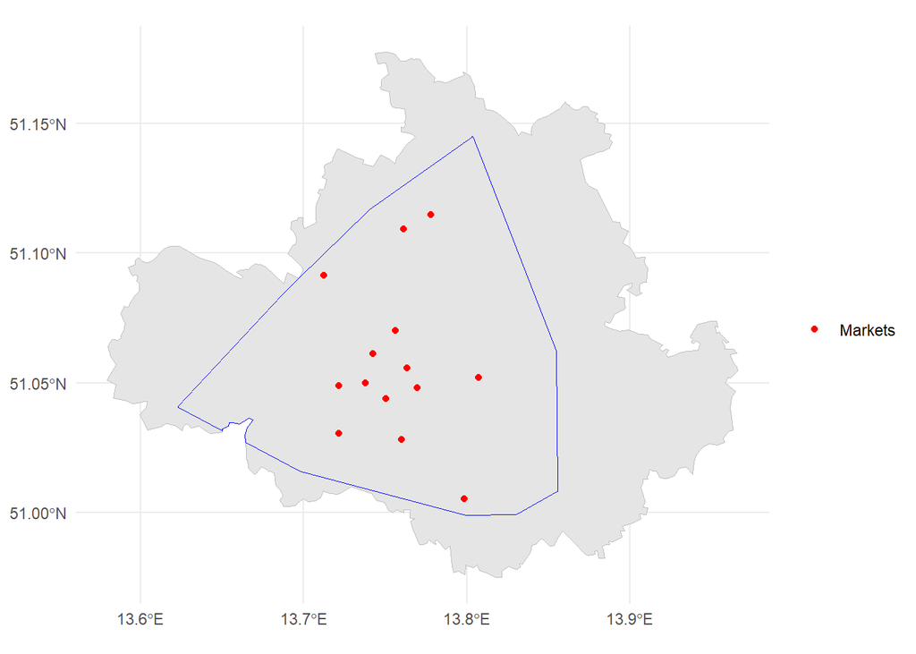

```r
market <- read.csv(here("data", "raw", "markets.csv"),sep=';')
market_sf <- st_as_sf(market, wkt = "geom")



market_area_plot <- ggplot()+
  geom_sf(data=dresden, colour="grey")+
  geom_sf(data=area_tram_sf, colour="blue")+
  geom_sf(data= market_sf, aes(fill= "Markets"),show.legend = "point",colour="red")+
  labs(fill="")+
  theme_minimal()

print(market_area_plot)
```

## Distances

Now let´s compute the distance from this room to the nearest market.

We will need the geolocation of this room, do get it we use the tidygeocoder package :

https://cran.r-project.org/web/packages/tidygeocoder/readme/README.html

That links the address to Open Street Maps to give us latitude and longitude.

```r
husse_bau <- tibble::tribble(
~name,~addr,
"Hülße-Bau der TU Dresden",  "Helmholtzstraße 10, 01069 Dresden")

# put the address on osm using geocode() with method = "osm"

hub_geocode <- husse_bau %>%
  geocode(addr, method = 'osm', lat = latitude , long = longitude)
```

```
## Passing 1 address to the Nominatim single address geocoder
```

```
## Query completed in: 1.5 seconds
```

```r
print(hub_geocode)
```

```
## # A tibble: 1 × 4
##   name                     addr                              latitude longitude
##   <chr>                    <chr>                                <dbl>     <dbl>
## 1 Hülße-Bau der TU Dresden Helmholtzstraße 10, 01069 Dresden     51.0      13.7
```

```r
# if you have the geolocation and want the address you can use reverse_geocode()

## we can convert the address to an sf object

hub_sf <- st_as_sf(hub_geocode, coords = c("longitude", "latitude"), crs = 4326)


str(hub_sf)
```

```
## sf [1 × 3] (S3: sf/tbl_df/tbl/data.frame)
##  $ name    : chr "Hülße-Bau der TU Dresden"
##  $ addr    : chr "Helmholtzstraße 10, 01069 Dresden"
##  $ geometry:sfc_POINT of length 1; first list element:  'XY' num [1:2] 13.7 51
##  - attr(*, "sf_column")= chr "geometry"
##  - attr(*, "agr")= Factor w/ 3 levels "constant","aggregate",..: NA NA
##   ..- attr(*, "names")= chr [1:2] "name" "addr"
```

Now let´s plot the husse bau in the map for a sanity check:

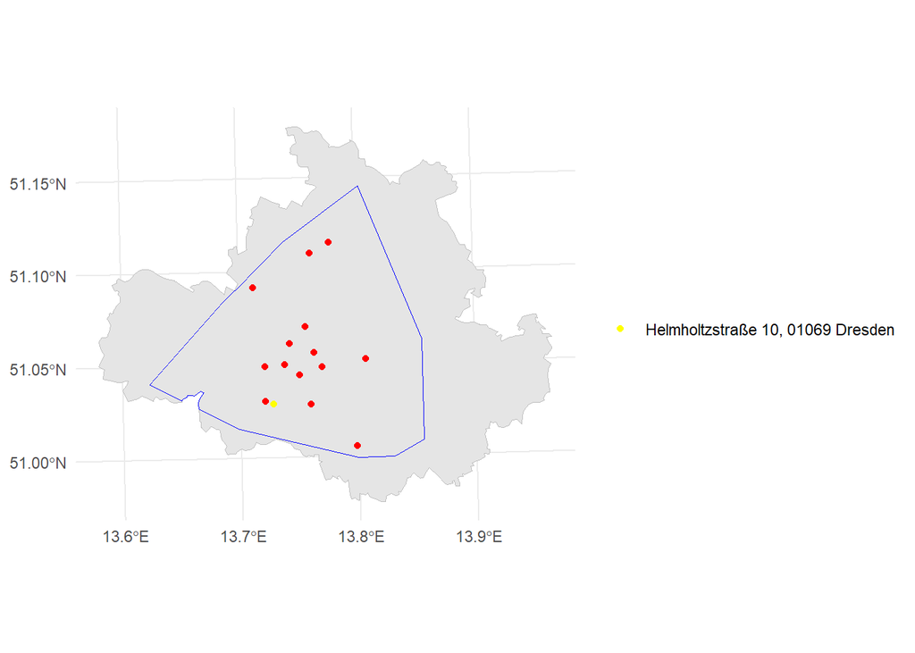

```r
ggplot() +
  geom_sf(data=dresden, colour="grey")+
  geom_sf(data=area_tram_sf, colour="blue")+
  geom_sf(data=market_sf, colour="red")+
  geom_sf(data = hub_sf,aes(fill = "Helmholtzstraße 10, 01069 Dresden"), color = "yellow") +
  coord_sf(crs=3398)+
  labs(fill="")+
  theme_minimal()
```

It looks correct and now we can compute the distance to the nearest market using the sf function st_distance() :

```r
## before computing the distance let´s make sure the crs is the same for both data

hub_rp <- st_transform(hub_sf, crs=3398)
market_rp <- st_transform(market_sf, crs=3398)

hus_market_rp <- st_distance(hub_rp, market_rp)
hus_market <- st_distance(hub_sf, market_sf)



## now there are many markets so the resulting object is a list of numbers expressed in a unit of measure (here the default that is meters (m))

str(hus_market)
```

```
##  Units: [m] num [1, 1:15] 3614 9258 5566 10186 3742 ...
```

```r
##We can assign these values to the list of markets from our market data

names(market_rp)
```

```
##  [1] "id"              "einrichtung"     "zeitraum"        "oeffnung"
##  [5] "einrichtungsart" "strasse"         "hnr"             "hnrz"
##  [9] "plz"             "fon"             "fax"             "url"
## [13] "e_mail"          "adr_nr"          "stadtteil"       "traeger"
## [17] "ds_modified"     "geom"
```

```r
## we will use id column

hus_df <- as.data.frame(hus_market)
hus_rp <- as.data.frame(hus_market_rp)

hus_t <- as.data.frame(t(hus_df))
hus_t_rp <- as.data.frame(t(hus_rp))

hus_t$id<- market$id
hus_t_rp$id<- market$id

## now we left_join the distance as a column using the id matches

market_hub_sf <- left_join(hus_t,market_sf, by="id")
market_hub_rp <- left_join(hus_t_rp, market_rp, by="id")

## we can table the distances

distance <- market_hub_sf |>
  dplyr::select("strasse", "V1")|>
  arrange(V1)

distance_rp <- market_hub_rp |>
  dplyr::select("strasse", "V1")|>
  arrange(V1)


print(distance)
```

```
##               strasse         V1
## 1     Münchener Platz   510.3567
## 2           Wasaplatz  2224.8707
## 3         Ammonstraße  2290.9899
## 4        Lingnerallee  2298.8414
## 5            Altmarkt  2441.8204
## 6            Altmarkt  2441.9112
## 7      Reißigerstraße  3614.1639
## 8         Königstraße  3742.4043
## 9        Bönischplatz  3883.0840
## 10         Alaunplatz  5002.5948
## 11 Jacob-Winter-Platz  5565.8144
## 12      Schillerplatz  6101.6789
## 13   Kopernikusstraße  7050.0232
## 14              Markt  9257.9446
## 15 Stralsunder Straße 10186.2312
```

```r
print(distance_rp)
```

```
##               strasse         V1
## 1     Münchener Platz   511.8682
## 2           Wasaplatz  2232.2936
## 3         Ammonstraße  2292.7806
## 4        Lingnerallee  2303.2038
## 5            Altmarkt  2443.9627
## 6            Altmarkt  2444.0534
## 7      Reißigerstraße  3622.8530
## 8         Königstraße  3745.6457
## 9        Bönischplatz  3889.8324
## 10         Alaunplatz  5008.0321
## 11 Jacob-Winter-Platz  5581.1404
## 12      Schillerplatz  6119.1634
## 13   Kopernikusstraße  7055.2289
## 14              Markt  9265.7641
## 15 Stralsunder Straße 10196.3160
```